# Forecasting NEPSE return using ARIMA

Roshan Rai

Sept 26, 2022

# **Time Series Analysis**

Time series includes observations recorded over time at regular intervals. A time series of length n is an ordered sequence of n observations recorded an equispaced instants and denoted by z1, z2, …., zn (Anderson 1995). It is the outcome of the observation of an underlying process in the course of which data are collected from measurements made at evenly spaced time intervals and in accordance to a specific sampling frequency. Thus, time series can be defined as a set of contiguous time instants (Esling and Agon 2012). The purpose of time series analysis is to understand the structure of time series data and to fit a model for forecasting. It can be used in economic forecasting, stock market analysis, sales forecasting, return projections. Different methods like Autoregression (AR), Moving Average (MR), Autoregressive Moving Average (ARMA), Autoregressive integrated Moving Average (ARIMA), Seasonal Autoregressive Integrated Moving Average (SARIMA) can be used for forecasting. For forecasting the NEPSE return, I have used the daily NEPSE index data from May 2013 to May 2023 which is aggregated for average monthly index during the period.

### **NEPSE index**

#### **Plot**

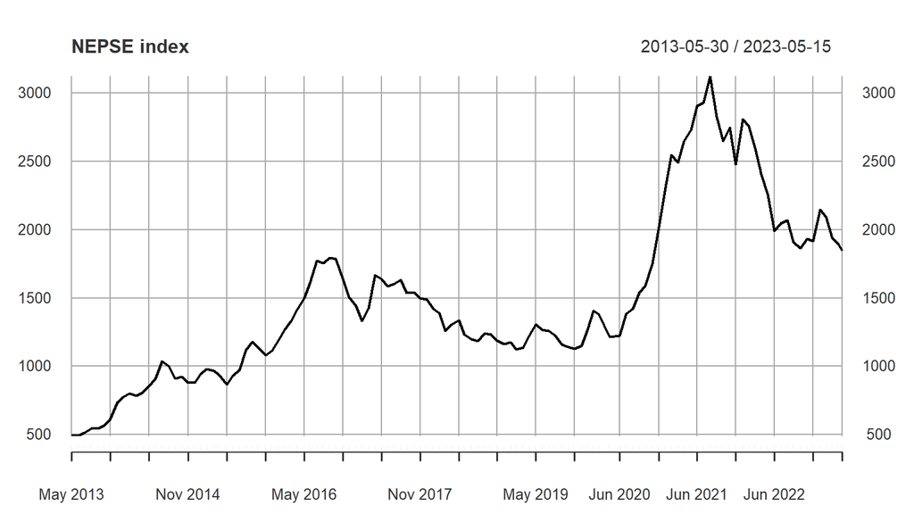

#### **Table**

| Date | Index |
| --- | --- |
| May 2013 | 499 |
| Jun 2013 | 494.43 |
| Jul 2013 | 516.87 |
| Aug 2013 | 543.44 |
| Sep 2013 | 546.95 |
| Oct 2013 | 568.21 |
| Nov 2013 | 615.85 |
| Dec 2013 | 736.35 |
| Jan 2014 | 777.65 |
| Feb 2014 | 801.83 |

[output cut: 110 more lines]

### **NEPSE return**

#### **Plot**

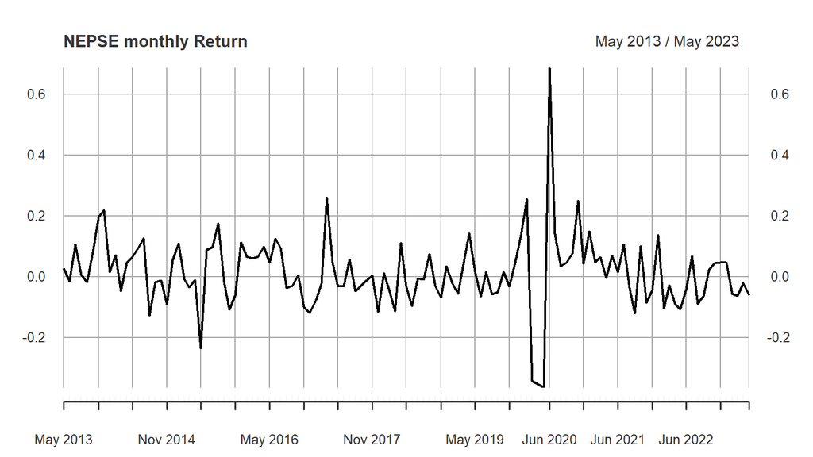

#### **Table**

| Date | Return in % |
| --- | --- |
| May 2013 | 2.6899 |
| Jun 2013 | -1.4667 |
| Jul 2013 | 10.6205 |
| Aug 2013 | 0.6694 |
| Sep 2013 | -1.7112 |
| Oct 2013 | 7.9319 |
| Nov 2013 | 19.6406 |
| Dec 2013 | 21.787 |
| Jan 2014 | 1.4272 |
| Feb 2014 | 7.0753 |

[output cut: 110 more lines]

## **Forecasting NEPSE Index**

## **ARIMA Model**

ARIMA stands for Autoregressive Integrated Moving Average is model for forecasting time series data by making the time series into stationary. The condition for ARIMA model is that the time series data must be stationary which can be made by differencing. A non seasonal ARIMA model is defined as **ARIMA(p,d,q)** model where; **p** is the number of autoregressive terms, **d** is the number of non seasonal differences needed for stationarity and **q** is the number of lagged forecast errors in the prediction equation. The ARIMA model is:

**Predicted Yt = Constant + Linear Combination Lags of Y (upto p lags) + Linear Combination of Lagged Forecast errors (upto q lags)**
$$Y_t = \alpha +
\beta_1Y_{t-1}+\beta_2Y_{t-2}+...+\beta_pY_{1-p}\epsilon_t+\phi_1\epsilon_{t-1}+\phi_2\epsilon_{t-2}+...\phi_q\epsilon_{t-q}$$
where,
$Y_{t-1}$ is the lag1 of the series,
$\beta_1$ is the coefficient of autoregressive model for lag 1 that the model estimate, and $\alpha$ is the constant.
Similarly, $\epsilon_{t-1}$ is the error term for lag 1 and $\phi_1$ is the coefficient of moving average model for lag 1.

If $d = 0: y_t = Y_t$  
If $d = 1: y_t = Y_t - Y_{t-1}$  
If $d = 2: y_t = (Y_t - Y_{t-1}) - (Y_{t-1} - Y_{t-2})$

### **Stationarity**

One of the important assumption of time series analysis is stationarity of time series. A strictly stationary time series is one for which the probabilistic behaviour of every collection of values${x_{t_1},x_{t_2},\ldots,x_{t_k}}$ is identical to that of time shifted set ${{x}_{t_1+h},\ x_{t_2+h},\ldots..,\ x_{t_k+h}}$ for all k = 1, 2, …, all time points t1, t2,….,tk and all time shifts $h = 0,\pm1,\pm2,\ldots..$ (Shumway 2011). A stationary time series has (i) constant mean for all time, (ii) constant variance for all time and, (iii) autocovariance function doesn’t depend on time. Majority of forecasting models assume the stationarity of time series. Non-stationary time series can be stationarized by differencing and transformation methods. A stationarized time series is comparatively easier to predict. Furthermore, the predictions from stationarized series can be untransformed by using whatever transformation method has been used to stationarize the series (University n.d.).

### **Model**

Using the **auto.arima()** function, it automatically stationarize the time series. The best model is ARIMA(1,0,3) for which the AIC is -178.63. For this model p = 1 is the AR term, d = 0 is the number of differencing required and q = 3 is the MA term. The coefficients of AR1, MA1, MA2 and MA3 are 0.772, -0.7069, -0.3452 and 0.3852.

```
## Series: nepse_monthly_return_ts
## ARIMA(1,0,3) with zero mean
##
## Coefficients:
##          ar1      ma1      ma2     ma3
##       0.7720  -0.7069  -0.3452  0.3852
## s.e.  0.1511   0.1576   0.1084  0.0915
##
## sigma^2 = 0.01253:  log likelihood = 94.32
## AIC=-178.63   AICc=-178.11   BIC=-164.7
```

### **Test of Stationarity test for model’s residuals**

The **acf** and **pacf** plots have very minimum number of vertical lines crossing the blue horizontal lines indicating the stationarity of the model.

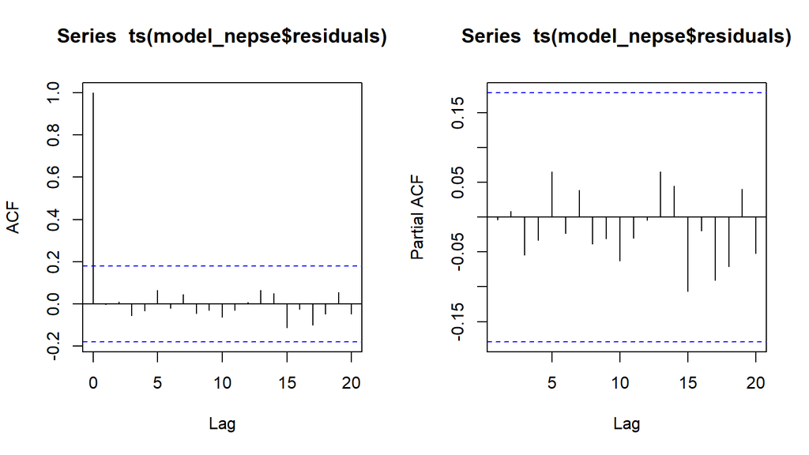

### **Forecasting**

#### **Plot**

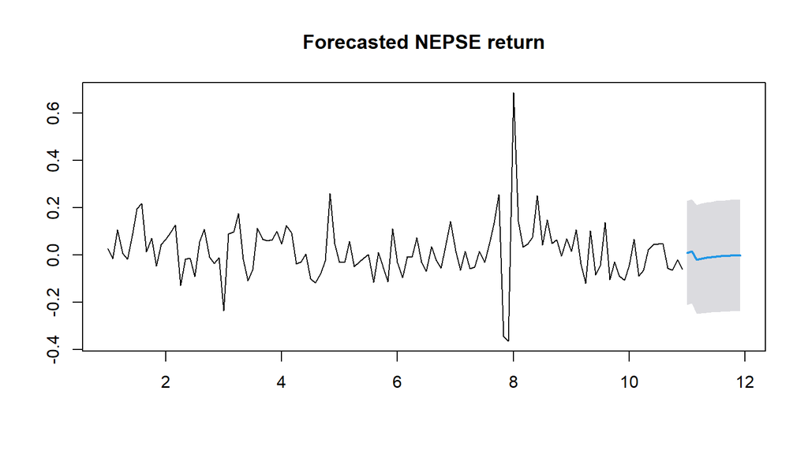

#### **Table**

[output not shown]

[output cut: 2 more lines]

## **Conclusion**

ARIMA is found to be more effective especially for short term time series forecasting. ARIMA model can increase the effectiveness of forecasting even with the minimum parameters. However, long term forecasting eventually goes to be straight line and it is poor at forecasting series with turning points (North Carolina n.d.).  
This blog explains the basic of ARIMA model and presents the process to perform the time series forecasting using this model. For more information regarding ARIMA model, visit [*here*](https://otexts.com/fpp2/arima.html). My code for time series analysis can be found [*here*](https://github.com/Roshann-Rai/time-series-gdp-nepse-rmd).  
Lastly all thanks to [*Code For Nepal*](https://codefornepal.org/) for providing me with opportunity to learn R.

## **References**

Anderson, Oliver D. 1995. “More Effective Time-Series Analysis and Forecasting.” *Journal of Computational and Applied Mathematics* 64 (1–2): 117–47. https://doi.org/10.1016/0377-0427(95)00011-9.

Esling, Philippe, and Carlos Agon. 2012. “Time-Series Data Mining.” *ACM Computing Surveys* 45 (1): 1–34. https://doi.org/10.1145/2379776.2379788.

North Carolina, University of. n.d. *Forecasting*. https://libres.uncg.edu/ir/uncw/f/zhai2005-2.pdf.

Shumway, & Stoffer, R. H. 2011. *Time Series Analysis and Its Application*. Springer.

University, Duke. n.d. *Stationarity and Differencing of Time Series Data*. https://people.duke.edu/~rnau/411diff.htm.